# **Big Data Analytics - Ανάλυση δεδομένων ηλεκτρικών οχημάτων**

# Τίτλος Εργασίας: Ανάλυση Μεγάλων Δεδομένων με Python

# Ονόματα μελών Ομάδας 5:

## - Διακογιάννης Αλέξιος Διονύσιος (UEL Number: 1911375),

## - Μανωλαράκης Αντώνιος (UEL Number: 2018464),

## - Τσολακίδης Κωνσταντίνος (UEL Number: 2877636)

## **Εισαγωγή**

Η ηλεκτροκίνηση αποτελεί μια από τις σημαντικότερες τεχνολογικές εξελίξεις στον τομέα των μεταφορών, καθώς συμβάλλει στη μείωση των εκπομπών διοξειδίου του άνθρακα και στη μετάβαση σε πιο βιώσιμες μορφές ενέργειας. Η ανάλυση δεδομένων ηλεκτρικών οχημάτων μπορεί να παρέχει πολύτιμες πληροφορίες για την κατανόηση των τάσεων αγοράς, της γεωγραφικής κατανομής και της χρήσης τους.

Στην παρούσα εργασία, θα αξιοποιήσουμε δεδομένα που περιέχουν πληροφορίες σχετικά με τον πληθυσμό ηλεκτρικών οχημάτων και θα εφαρμόσουμε τεχνικές ανάλυσης δεδομένων με τη χρήση **PySpark**. Η εργασία στοχεύει να απαντήσει σε ερωτήματα όπως:

- Ποιες είναι οι κυρίαρχες μάρκες και μοντέλα ηλεκτρικών οχημάτων;
- Πώς κατανέμονται γεωγραφικά τα ηλεκτρικά οχήματα;
- Ποια είναι τα πιο συνηθισμένα χαρακτηριστικά των ηλεκτρικών οχημάτων;
- Πώς μπορούν τα δεδομένα αυτά να χρησιμοποιηθούν για τη χάραξη πολιτικής και τη βελτίωση των υποδομών ηλεκτροκίνησης;

Η προσέγγισή μας περιλαμβάνει την **καθαριότητα και προετοιμασία των δεδομένων, την εφαρμογή ανάλυσης μέσω PySpark SQL και την εξαγωγή συμπερασμάτων**.

## **Πίνακας Περιεχομένων**

1. Εισαγωγή
2. Βιβλιογραφική Ανασκόπηση
3. Περιγραφή και Προετοιμασία των Δεδομένων
4. Εξερεύνηση και Στατιστική Ανάλυση
5. Ανάλυση με PySpark SQL
6. Συμπεράσματα και Μελλοντικές Επεκτάσεις

# **2. Βιβλιογραφική Ανασκόπηση**

## **2.1 Ηλεκτρικά Οχήματα και Οικολογική Μετάβαση**

Τα ηλεκτρικά οχήματα (EVs) αποτελούν κεντρικό άξονα της παγκόσμιας μετάβασης προς καθαρότερες μορφές ενέργειας. Σύμφωνα με μελέτες (IEA, 2023), η αύξηση της χρήσης EVs έχει συμβάλλει στη μείωση των εκπομπών CO₂ και στη μείωση της εξάρτησης από ορυκτά καύσιμα. Ο αριθμός των ηλεκτρικών οχημάτων έχει αυξηθεί σημαντικά τα τελευταία χρόνια, με την Κίνα, τις ΗΠΑ και την Ευρώπη να ηγούνται της αγοράς.

Η ανάλυση δεδομένων ηλεκτρικών οχημάτων παρέχει πληροφορίες σχετικά με τις τάσεις αγοράς, τη χρήση και την κατανομή τους. Η πρόσβαση σε δεδομένα πραγματικού κόσμου επιτρέπει τη λήψη αποφάσεων από κυβερνήσεις και επιχειρήσεις για τη βελτίωση των υποδομών φόρτισης και την ανάπτυξη νέων πολιτικών.

## **2.2 Big Data και Ανάλυση Δεδομένων στην Ηλεκτροκίνηση**

Η ανάλυση μεγάλων δεδομένων (**Big Data Analytics**) έχει βρει εφαρμογή σε διάφορους τομείς, συμπεριλαμβανομένης της αυτοκινητοβιομηχανίας. Τα δεδομένα που προέρχονται από ηλεκτρικά οχήματα (π.χ. αισθητήρες, GPS, σταθμοί φόρτισης) επιτρέπουν την ανακάλυψη προτύπων και τη βελτιστοποίηση των υπηρεσιών μετακίνησης.

Η χρήση τεχνολογιών όπως **Apache Spark και PySpark** επιτρέπει την αποτελεσματική ανάλυση μεγάλων συνόλων δεδομένων, ενώ τα εργαλεία μηχανικής μάθησης (ML) επιτρέπουν την πρόβλεψη τάσεων και τη λήψη αποφάσεων βασισμένων σε δεδομένα.

Μεθοδολογίες όπως:

- **Στατιστική ανάλυση** για την περιγραφή των δεδομένων.
- **Ανάλυση PySpark SQL** για την αναζήτηση μοτίβων.
- **Μηχανική μάθηση** για πιθανές προβλέψεις σχετικά με την ανάπτυξη της ηλεκτροκίνησης.

## **2.3 Προηγούμενες Έρευνες και Συναφή Εργαλεία**

Προηγούμενες έρευνες έχουν επικεντρωθεί στην ανάλυση δεδομένων ηλεκτρικών οχημάτων, όπως:

- Μελέτες πάνω στη **γεωγραφική κατανομή των EVs** (Chen et al., 2022).
- Ανάλυση της **αποδοτικότητας μπαταριών και δικτύων φόρτισης** (Liu et al., 2021).
- **Αναλύσεις αγοράς** που προσδιορίζουν τις τάσεις κατανάλωσης και τις προτιμήσεις καταναλωτών.

Η χρήση εργαλείων όπως το **Apache Spark** έχει αποδειχθεί αποτελεσματική στην επεξεργασία μεγάλων δεδομένων. Το PySpark επιτρέπει **γρήγορη ανάλυση δεδομένων**, ενώ η ενσωμάτωση με **Pandas και Matplotlib** βοηθά στην οπτικοποίηση αποτελεσμάτων.

## **2. Θεωρητικό Πλαίσιο**

Η ανάλυση μεγάλων δεδομένων (**Big Data Analytics**) έχει αναδειχθεί ως μια από τις πιο σημαντικές τεχνολογικές προόδους της τελευταίας δεκαετίας. Με την αυξανόμενη διαθεσιμότητα δεδομένων από διάφορους τομείς, οι σύγχρονες μεθοδολογίες ανάλυσης επιτρέπουν την εξαγωγή χρήσιμων πληροφοριών, την πρόβλεψη τάσεων και τη βελτιστοποίηση διαδικασιών.

### **2.1. Big Data Analytics: Ορισμός και Σημασία**

Τα **Big Data Analytics** αφορούν τις τεχνικές και τις τεχνολογίες που χρησιμοποιούνται για την αποθήκευση, επεξεργασία και ανάλυση μεγάλου όγκου δεδομένων, τα οποία είναι συχνά μη δομημένα ή ημι-δομημένα. Χαρακτηρίζονται από τις **5Vs**:

- **Volume (Όγκος):** Τεράστιος όγκος δεδομένων που δημιουργείται καθημερινά.
- **Velocity (Ταχύτητα):** Τα δεδομένα παράγονται και επεξεργάζονται σε πραγματικό χρόνο.
- **Variety (Ποικιλία):** Διάφορες μορφές δεδομένων (δομημένα, μη δομημένα, εικόνες, IoT δεδομένα).
- **Veracity (Αξιοπιστία):** Η ανάγκη για καθαρά και αξιόπιστα δεδομένα.
- **Value (Αξία):** Η μετατροπή των δεδομένων σε χρήσιμες πληροφορίες για λήψη αποφάσεων.

### **2.2. Big Data στις Μεταφορές**

Η υιοθέτηση των Big Data Analytics στις μεταφορές έχει φέρει επανάσταση στην ανάλυση δεδομένων κινητικότητας. Μέσω της συλλογής δεδομένων από αισθητήρες, GPS, εφαρμογές κινητών και έξυπνες υποδομές, είναι δυνατή η μελέτη προτύπων κυκλοφορίας, η βελτίωση των δημόσιων συγκοινωνιών και η ανάπτυξη στρατηγικών βιώσιμης κινητικότητας.

### **2.3. Ηλεκτρικά Οχήματα και Δεδομένα**

Η ραγδαία αύξηση των ηλεκτρικών οχημάτων (**EVs**) έχει δημιουργήσει νέες προκλήσεις και ευκαιρίες στη διαχείριση και ανάλυση δεδομένων. Τα δεδομένα που σχετίζονται με τα EVs περιλαμβάνουν:

- Κατασκευαστές και μοντέλα οχημάτων.
- Χωρητικότητα μπαταρίας και αυτονομία.
- Σταθμούς φόρτισης και πρότυπα σύνδεσης.
- Περιβαλλοντικές επιπτώσεις και κατανάλωση ενέργειας.

Η ανάλυση αυτών των δεδομένων μπορεί να οδηγήσει σε **βελτιστοποίηση της χρήσης των ηλεκτρικών οχημάτων, πρόβλεψη αναγκών φόρτισης και εντοπισμό εμποδίων στην υιοθέτησή τους**.

### **2.4. Μεθοδολογίες και Τεχνολογίες που θα χρησιμοποιηθούν**

Για την ανάλυση του dataset των ηλεκτρικών οχημάτων, θα εφαρμοστούν οι ακόλουθες τεχνικές:

- **Εξερεύνηση δεδομένων (Exploratory Data Analysis - EDA):** Οπτικοποίηση και ανάλυση χαρακτηριστικών του dataset.
- **Στατιστική Ανάλυση:** Κατανόηση των σχέσεων μεταξύ των μεταβλητών.
- **Μηχανική Μάθηση (Machine Learning):** Ανάπτυξη μοντέλων πρόβλεψης (αν κριθεί αναγκαίο).
- **Big Data Tools:** Χρήση βιβλιοθηκών όπως **Pandas, Seaborn, Matplotlib, Plotly**, καθώς και πιθανή χρήση **PySpark για μεγάλα datasets**.

## **3. Προεπεξεργασία των Δεδομένων**

Πριν προχωρήσουμε στην ανάλυση των δεδομένων, είναι απαραίτητο να εξετάσουμε τη δομή του dataset, να εντοπίσουμε ελλείπουσες ή ανώμαλες τιμές και να εφαρμόσουμε τις κατάλληλες τεχνικές προεπεξεργασίας.

### **3.1. Επισκόπηση του Dataset**

Ξεκινάμε φορτώνοντας το dataset και εξετάζοντας τη δομή του:

```python
#Φορτώνουμε απο Google Drive

# from google.colab import drive
# drive.mount('/content/drive')
file_path = 'Electric_Vehicle_Population_Data.csv'

import pandas as pd
df = pd.read_csv(file_path)
```

```python
# Βασικές πληροφορίες για το dataset
df.info()

# Εμφάνιση των πρώτων 5 γραμμών του dataset
df.head()
```

```
<class 'pandas.core.frame.DataFrame'>
RangeIndex: 220225 entries, 0 to 220224
Data columns (total 17 columns):
 #   Column                                             Non-Null Count   Dtype
---  ------                                             --------------   -----
 0   VIN (1-10)                                         220225 non-null  object
 1   County                                             220222 non-null  object
 2   City                                               220222 non-null  object
 3   State                                              220225 non-null  object
 4   Postal Code                                        220222 non-null  float64
 5   Model Year                                         220225 non-null  int64
 6   Make                                               220225 non-null  object
 7   Model                                              220225 non-null  object
 8   Electric Vehicle Type                              220225 non-null  object
 9   Clean Alternative Fuel Vehicle (CAFV) Eligibility  220225 non-null  object
 10  Electric Range                                     220225 non-null  int64
 11  Base MSRP                                          220225 non-null  int64
 12  Legislative District                               219762 non-null  float64
 13  DOL Vehicle ID                                     220225 non-null  int64
 14  Vehicle Location                                   220216 non-null  object
 15  Electric Utility                                   220222 non-null  object
 16  2020 Census Tract                                  220222 non-null  float64
dtypes: float64(3), int64(4), object(10)
memory usage: 28.6+ MB
```

|  | VIN (1-10) | County | City | State | Postal Code | Model Year | Make | Model | Electric Vehicle Type | Clean Alternative Fuel Vehicle (CAFV) Eligibility | Electric Range | Base MSRP | Legislative District | DOL Vehicle ID | Vehicle Location | Electric Utility | 2020 Census Tract |
| --- | --- | --- | --- | --- | --- | --- | --- | --- | --- | --- | --- | --- | --- | --- | --- | --- | --- |
| 0 | 5YJ3E1EA5L | King | Seattle | WA | 98133.0 | 2020 | TESLA | MODEL 3 | Battery Electric Vehicle (BEV) | Clean Alternative Fuel Vehicle Eligible | 266 | 0 | 46.0 | 249903111 | POINT (-122.35029 47.71871) | CITY OF SEATTLE - (WA)\|CITY OF TACOMA - (WA) | 5.303300e+10 |
| 1 | 5UX43EU08R | King | Seattle | WA | 98125.0 | 2024 | BMW | X5 | Plug-in Hybrid Electric Vehicle (PHEV) | Clean Alternative Fuel Vehicle Eligible | 39 | 0 | 46.0 | 264762606 | POINT (-122.30253 47.72656) | CITY OF SEATTLE - (WA)\|CITY OF TACOMA - (WA) | 5.303300e+10 |
| 2 | 5UX43EU06R | King | Seattle | WA | 98102.0 | 2024 | BMW | X5 | Plug-in Hybrid Electric Vehicle (PHEV) | Clean Alternative Fuel Vehicle Eligible | 39 | 0 | 43.0 | 275506031 | POINT (-122.32427 47.63433) | CITY OF SEATTLE - (WA)\|CITY OF TACOMA - (WA) | 5.303301e+10 |
| 3 | 5YJ3E1EA1J | King | Kirkland | WA | 98034.0 | 2018 | TESLA | MODEL 3 | Battery Electric Vehicle (BEV) | Clean Alternative Fuel Vehicle Eligible | 215 | 0 | 1.0 | 117023581 | POINT (-122.22901 47.72201) | PUGET SOUND ENERGY INC\|\|CITY OF TACOMA - (WA) | 5.303302e+10 |
| 4 | 1G1RA6E43C | Thurston | Olympia | WA | 98501.0 | 2012 | CHEVROLET | VOLT | Plug-in Hybrid Electric Vehicle (PHEV) | Clean Alternative Fuel Vehicle Eligible | 35 | 0 | 35.0 | 158415498 | POINT (-122.89166 47.03956) | PUGET SOUND ENERGY INC | 5.306701e+10 |

```python
# Εισαγωγή απαραίτητων βιβλιοθηκών
import pandas as pd
import numpy as np
import matplotlib.pyplot as plt
import seaborn as sns
from scipy.stats.mstats import winsorize

# Έλεγχος για missing values
missing_values = df.isnull().sum()
missing_values = missing_values[missing_values > 0]  # Διατηρούμε μόνο όσες έχουν NaN
missing_values
```

```
County                    3
City                      3
Postal Code               3
Legislative District    463
Vehicle Location          9
Electric Utility          3
2020 Census Tract         3
dtype: int64
```

### **3.2 Οπτικοποίηση των Μηδενικών Τιμών**

Χρησιμοποιούμε τη seaborn για να απεικονίσουμε τις στήλες με ελλιπή δεδομένα.

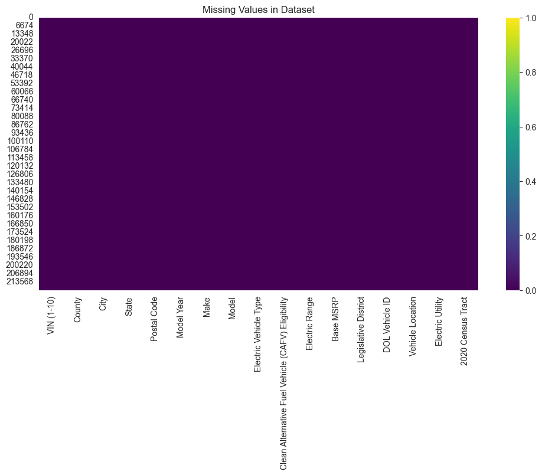

```python
# Οπτικοποίηση των NaN values
plt.figure(figsize=(12,6))
sns.heatmap(df.isnull(), cbar=True, cmap='viridis')
plt.title('Missing Values in Dataset')
plt.show()
```

### **3.3 Οπτικοποίηση της Κατανομής των Κατασκευαστών**

Για να δούμε ποιοι κατασκευαστές ηλεκτρικών οχημάτων υπάρχουν στο dataset και τη συχνότητά τους.

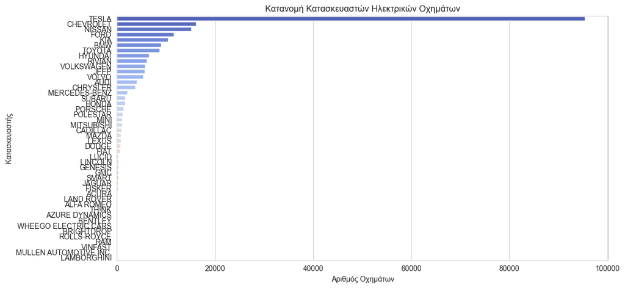

```python
plt.figure(figsize=(12,6))
sns.countplot(y=df['Make'], order=df['Make'].value_counts().index, palette="coolwarm")
plt.title("Κατανομή Κατασκευαστών Ηλεκτρικών Οχημάτων")
plt.xlabel("Αριθμός Οχημάτων")
plt.ylabel("Κατασκευαστής")
plt.show()
```

### **3.4 Ιστόγραμμα των Αριθμητικών Μεταβλητών**

Για να κατανοήσουμε την κατανομή των τιμών στα αριθμητικά πεδία.

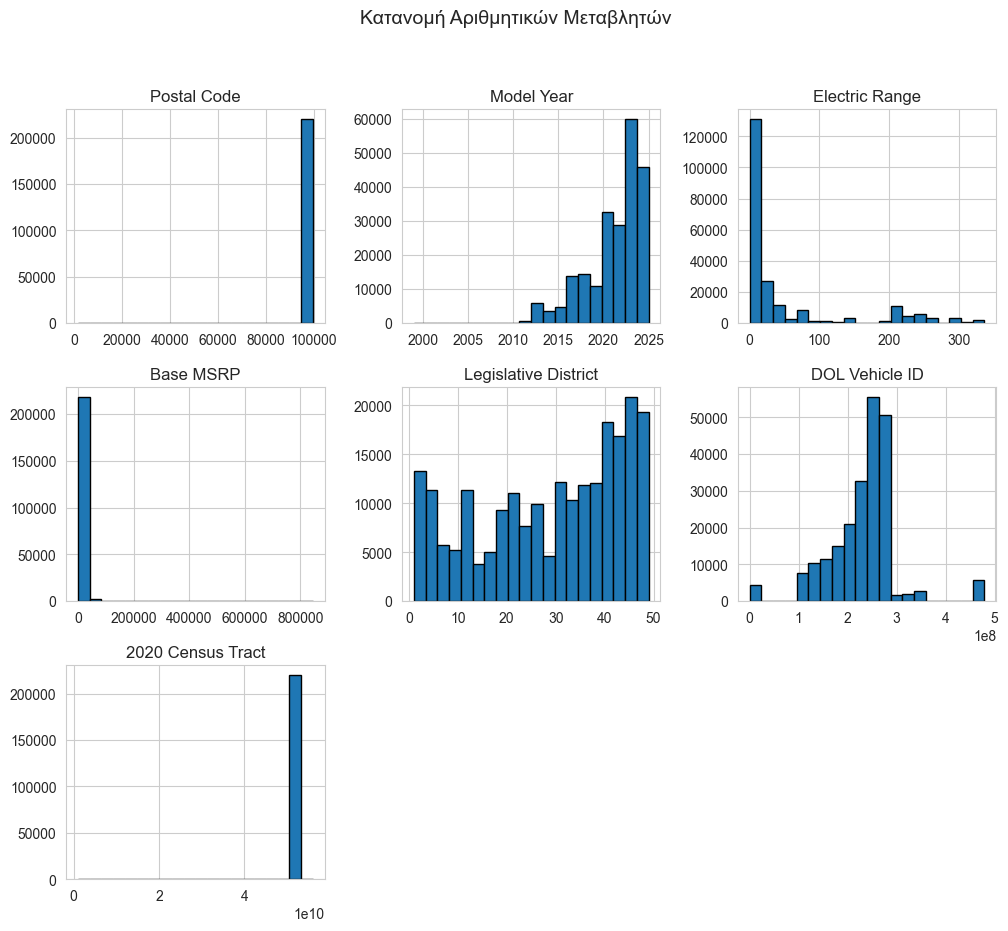

```python
# Ιστόγραμμα για όλες τις αριθμητικές μεταβλητές
df.hist(figsize=(12,10), bins=20, edgecolor='black')
plt.suptitle("Κατανομή Αριθμητικών Μεταβλητών", fontsize=14)
plt.show()
```

**Boxplot για τον Εντοπισμό Ακραίων Τιμών**

Εξετάζουμε πιθανές ακραίες τιμές στα δεδομένα της αυτονομίας μπαταρίας.

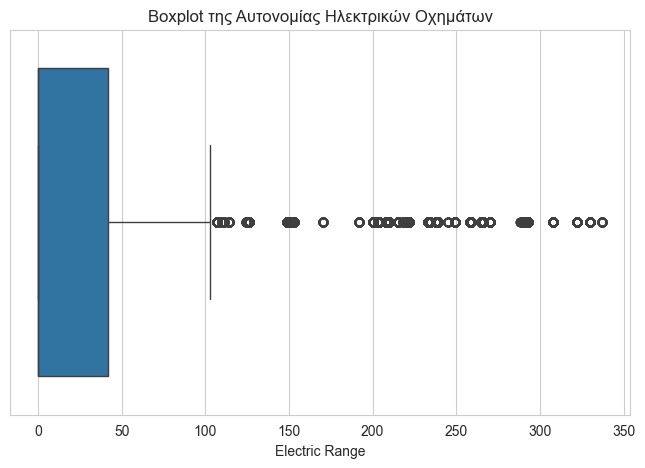

```python
plt.figure(figsize=(8,5))
sns.boxplot(x=df['Electric Range'])
plt.title("Boxplot της Αυτονομίας Ηλεκτρικών Οχημάτων")
plt.show()
```

επειδή φαίνεται ότι πολλά οχήματα έχουν αυτονομία μηδέν και αυτό δεν είναι σωστό, τα εντοπίζουμε για να δουμε την αιτία.

```python
# Υπολογισμός των εγγραφών με Electric Range = 0
zero_range_count = (df['Electric Range'] == 0).sum()
non_zero_range_count  = (df['Electric Range'] != 0).sum()

print(f"Zero Range Count: {zero_range_count}")
print(f"Non-Zero Range Count: {non_zero_range_count}")
print(f"Ποσοστό μηδενικών τιμών: {zero_range_count / len(df) * 100:.2f}%")
```

```
Zero Range Count: 127319
Non-Zero Range Count: 92906
Ποσοστό μηδενικών τιμών: 57.81%
```

Θα προσπαθήσουμε να βρούμε τι κοινό έχουν τα αυτοκίνητα με Electric Range = 0

```python
print(df[df['Electric Range'] == 0].head(10))
```

```
    VIN (1-10)     County       City State  Postal Code  Model Year  \
5   1V2CMPE88P     Yakima      Selah    WA      98942.0        2023
6   KNDAFFS57R     Yakima     Yakima    WA      98908.0        2024
9   KNDCC3LG4N     Yakima     Yakima    WA      98908.0        2022
10  7FCTGBAA7R   Thurston     Tenino    WA      98589.0        2024
28  7FCTGAAAXP     Kitsap  Bremerton    WA      98310.0        2023
31  JTMABACA6R     Kitsap  Bremerton    WA      98310.0        2024
49  5YJ3E1EA4P  Snohomish     Monroe    WA      98272.0        2023
55  WA1AAAGE1N     Yakima     Yakima    WA      98902.0        2022
69  7SAYGDEE7P  Snohomish    Bothell    WA      98012.0        2023
70  7SAYGDEE3P  Snohomish    Bothell    WA      98021.0        2023

          Make    Model           Electric Vehicle Type  \
5   VOLKSWAGEN     ID.4  Battery Electric Vehicle (BEV)
6          KIA      EV9  Battery Electric Vehicle (BEV)
```

[output cut: 44 more lines]

Παρτηρούμε ότι ὀλα τα αυτοκίνητα με Electric Range = 0, στην στήλη Clean Alternative Fuel Vehicle (CAFV) Eligibility έχουν την τιμή "Eligibility unknown as battery range has not been researched"

Ας ερευνήσουμε αν κάθε αυτοκίνητο με "Eligibility unknown as battery range has not been researched" έχει Electric Range = 0

Φιλτράρουμε τα δεδομένα για να βρούμε τα αυτοκίνητα με "Eligibility unknown as battery range has not been researched"

```python
unknown_eligibility_df = df[
 df['Clean Alternative Fuel Vehicle (CAFV) Eligibility']
 .str.contains('Eligibility unknown as battery range has not been determined', na=False)
]

# Ελέγχουμε αν όλα τα αυτοκίνητα έχουν Electric Range = 0
if (unknown_eligibility_df['Electric Range'] == 0).all():
 print("Όλα τα αυτοκίνητα με 'Eligibility unknown as battery range has not been researched' έχουν Electric Range = 0.")
else:
 print("Υπάρχουν αυτοκίνητα με 'Eligibility unknown as battery range has not been researched' που δεν έχουν Electric Range = 0.")
```

```
Όλα τα αυτοκίνητα με 'Eligibility unknown as battery range has not been researched' έχουν Electric Range = 0.
```

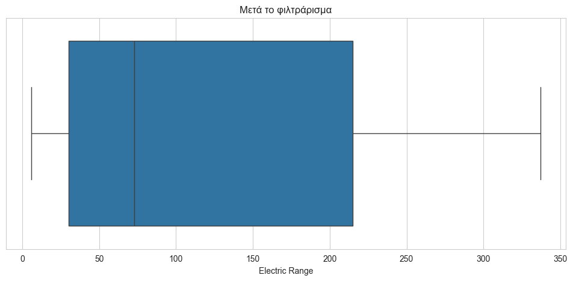

```python
# Δημιουργούμε ένα νέο DataFrame που περιέχει μόνο γραμμές όπου το Electric Range δεν είναι 0
df_cleaned = df[df['Electric Range'] != 0].copy()
df = df_cleaned

plt.figure(figsize=(12,5))

# Boxplot μετα το φιλτράρισμα
sns.boxplot(x=df['Electric Range'])
plt.title("Μετά το φιλτράρισμα")



plt.show()
```

### **Κατανομή Δεδομένων μετά το Φιλτράρισμα**

Για να κατανοήσουμε καλύτερα πώς η κατανομή μεταβλήθηκε, δημιουργούμε το παρακάτω **ιστόγραμμα**. Παρατηρούμε ότι μετά την αφαίρεση των outliers:

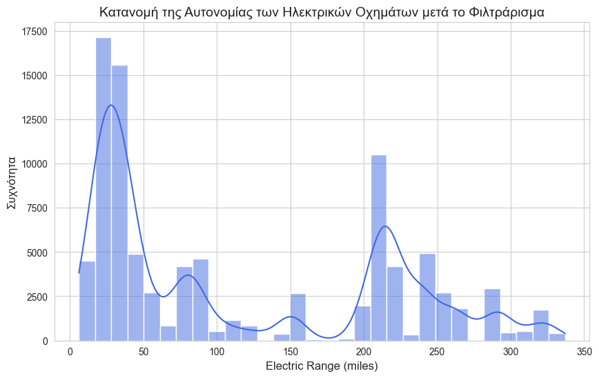

```python
# Ρύθμιση μεγέθους διαγράμματος
plt.figure(figsize=(10, 6))

# Ιστόγραμμα για το Electric Range μετά την αφαίρεση των Outliers
sns.histplot(df['Electric Range'], bins=30, kde=True, color="royalblue")

# Τίτλος και ετικέτες
plt.title("Κατανομή της Αυτονομίας των Ηλεκτρικών Οχημάτων μετά το Φιλτράρισμα", fontsize=14)
plt.xlabel("Electric Range (miles)", fontsize=12)
plt.ylabel("Συχνότητα", fontsize=12)

# Εμφάνιση διαγράμματος
plt.show()
```

## **3.5 Στατιστική Ανάλυση των Δεδομένων**

Σε αυτό το στάδιο, θα εξετάσουμε τις βασικές στατιστικές ιδιότητες του dataset μας μετά τον καθαρισμό των δεδομένων.

### **3.5.1 Υπολογισμός Βασικών Στατιστικών Μέτρων**

Χρησιμοποιούμε τη συνάρτηση `.describe()` της `pandas` για να λάβουμε τις βασικές στατιστικές τιμές του dataset.

```python
# Υπολογισμός βασικών στατιστικών μέτρων για τα αριθμητικά πεδία
df.describe()
```

|  | Postal Code | Model Year | Electric Range | Base MSRP | Legislative District | DOL Vehicle ID | 2020 Census Tract |
| --- | --- | --- | --- | --- | --- | --- | --- |
| count | 92904.000000 | 92906.000000 | 92906.000000 | 92906.000000 | 92676.000000 | 9.290600e+04 | 9.290400e+04 |
| mean | 98184.196472 | 2018.915054 | 115.496696 | 2020.669440 | 28.506798 | 2.209368e+08 | 5.297314e+10 |
| std | 2766.326770 | 3.276343 | 98.834749 | 11396.560558 | 14.649595 | 9.877439e+07 | 1.610967e+09 |
| min | 1970.000000 | 1999.000000 | 6.000000 | 0.000000 | 1.000000 | 4.385000e+03 | 1.001020e+09 |
| 25% | 98057.000000 | 2017.000000 | 30.000000 | 0.000000 | 17.000000 | 1.523003e+08 | 5.303301e+10 |
| 50% | 98168.000000 | 2019.000000 | 73.000000 | 0.000000 | 32.000000 | 2.285220e+08 | 5.303303e+10 |
| 75% | 98405.000000 | 2021.000000 | 215.000000 | 0.000000 | 41.000000 | 2.657967e+08 | 5.305307e+10 |
| max | 99403.000000 | 2025.000000 | 337.000000 | 845000.000000 | 49.000000 | 4.792548e+08 | 5.500902e+10 |

### **Σημαντικά Σημεία**

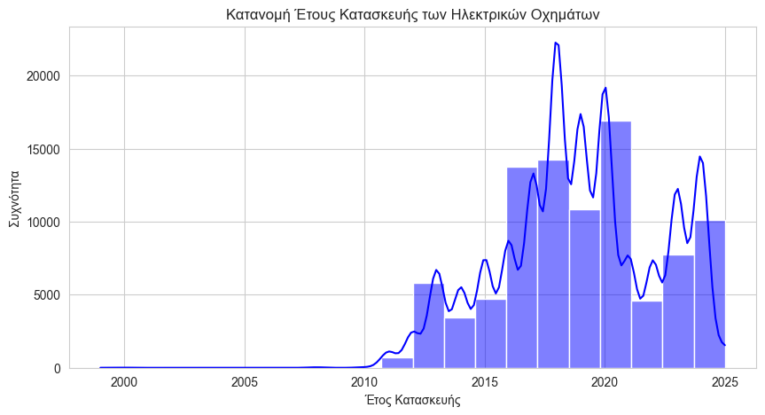

```python
# Ορισμός στυλ για τα διαγράμματα
sns.set_style("whitegrid")

# Κατανομή Έτους Κατασκευής (Model Year)
plt.figure(figsize=(10, 5))
sns.histplot(df['Model Year'], bins=20, kde=True, color='blue')
plt.title("Κατανομή Έτους Κατασκευής των Ηλεκτρικών Οχημάτων")
plt.xlabel("Έτος Κατασκευής")
plt.ylabel("Συχνότητα")
plt.show()
```

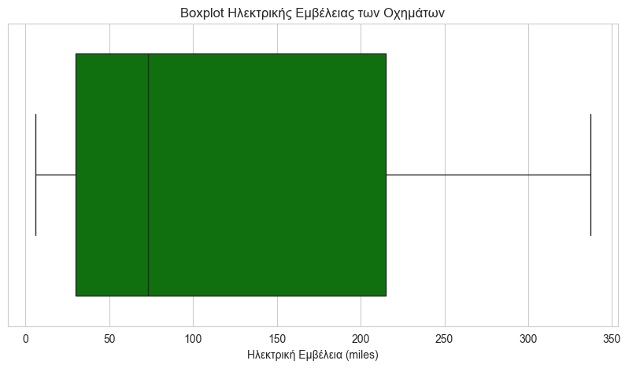

```python
# Boxplot Κατανάλωσης Ενέργειας (Electric Range)
plt.figure(figsize=(10, 5))
sns.boxplot(x=df['Electric Range'], color='green')
plt.title("Boxplot Ηλεκτρικής Εμβέλειας των Οχημάτων")
plt.xlabel("Ηλεκτρική Εμβέλεια (miles)")
plt.show()
```

Παρατηρούμε μεγάλη διακύμανση στην ηλεκτρική αυτονομία. Ορισμένα οχήματα έχουν πολύ χαμηλή αυτονομία (<50 miles), ενώ κάποια φτάνουν σχεδόν 350 miles. Δεν υπάρχουν outliers.

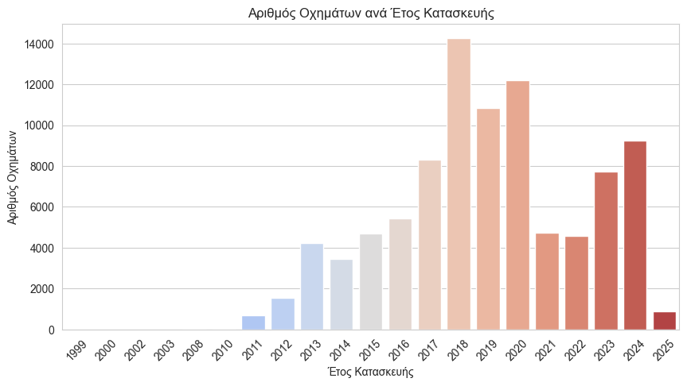

```python
# Bar Plot για Έτος Κατασκευής
plt.figure(figsize=(10, 5))
sns.countplot(x=df['Model Year'], order=sorted(df['Model Year'].unique()), palette='coolwarm')
plt.title("Αριθμός Οχημάτων ανά Έτος Κατασκευής")
plt.xlabel("Έτος Κατασκευής")
plt.ylabel("Αριθμός Οχημάτων")
plt.xticks(rotation=45)
plt.show()
```

```python
# Υπολογισμός των πωλήσεων EV ανά έτος
ev_sales_per_year = df['Model Year'].value_counts().sort_index()

# Έλεγχος αν υπάρχουν δεδομένα για το 2023 και 2024
sales_2023 = ev_sales_per_year.get(2023, 0)
sales_2024 = ev_sales_per_year.get(2024, 0)

reduction_percentage = ((sales_2023 - sales_2024) / sales_2023) * 100
print(f"Μείωση πωλήσεων EV το 2024 σε σχέση με το 2023: {reduction_percentage:.2f}%")
```

[output not shown]

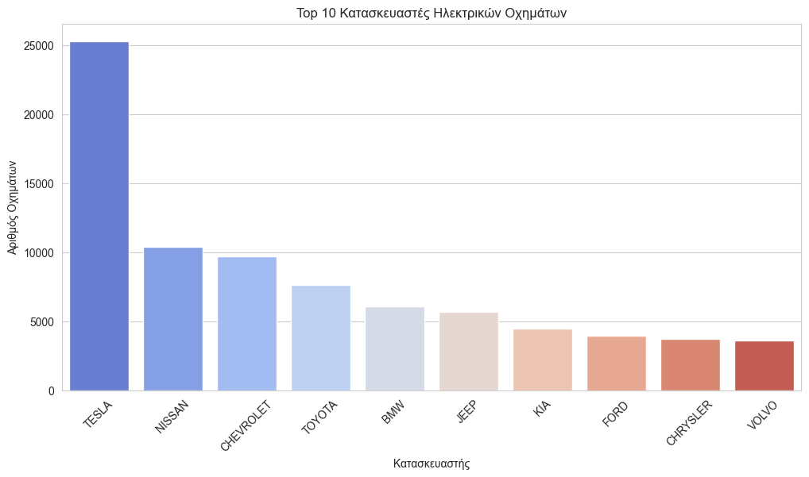

```python
top_manufacturers = df['Make'].value_counts().nlargest(10)  # Οι 10 κορυφαίοι κατασκευαστές

plt.figure(figsize=(12,6))
sns.barplot(x=top_manufacturers.index, y=top_manufacturers.values, palette="coolwarm")
plt.xlabel("Κατασκευαστής")
plt.ylabel("Αριθμός Οχημάτων")
plt.title("Top 10 Κατασκευαστές Ηλεκτρικών Οχημάτων")
plt.xticks(rotation=45)
plt.show()
```

## **3.5.3 Ανάλυση της Κατανομής των Ηλεκτρικών Οχημάτων**

Σε αυτή την ενότητα, θα εξετάσουμε τη γεωγραφική κατανομή των ηλεκτρικών οχημάτων, την πυκνότητά τους σε διάφορες περιοχές και τις τάσεις που προκύπτουν από τα δεδομένα.

### **Γεωγραφική Κατανομή των Ηλεκτρικών Οχημάτων**

Η ανάλυση των δεδομένων περιλαμβάνει τη μελέτη της συγκέντρωσης ηλεκτρικών οχημάτων ανά περιοχή. Χρησιμοποιούμε γεωγραφικά δεδομένα (όπως ταχυδρομικούς κώδικες ή πόλεις) για να προσδιορίσουμε περιοχές με υψηλή υιοθέτηση ηλεκτρικών οχημάτων. Γι αυτό θα χρησημοποιήσουμε ένα ακόμα dataset.

#### **Οπτικοποίηση της Κατανομής με Χάρτη**

Θα δημιουργήσουμε ένα heatmap που θα απεικονίζει την πυκνότητα των ηλεκτρικών οχημάτων σε διαφορετικές περιοχές.

```python
# Φόρτωση των δεδομένων με τις συντεταγμένες
zip_lat_long_path = 'zip_lat_long.csv'
df_geo = pd.read_csv(zip_lat_long_path)

# Εμφάνιση των πρώτων γραμμών για επιβεβαίωση
#print(df_geo.head())

df = df.rename(columns={'ZIP': 'ZIP Code'}) # για να μην παρουμε error λογο των dublicate columns

# Συγχώνευση των δεδομένων με βάση τον ταχυδρομικό κώδικα
df = df.merge(df_geo, how='left', left_on='Postal Code', right_on='ZIP')

df = df.rename(columns={'LAT': 'Latitude'})
df = df.rename(columns={'LNG': 'Longitude'})



# Έλεγχος αν προστέθηκαν σωστά οι συντεταγμένες
#print(df[['ZIP', 'Latitude', 'Longitude']].head())
```

### **3.5.4 Οπτικοποίηση των Σημείων στο Χάρτη**

```python
import pandas as pd
import folium
from folium.plugins import HeatMap

# 🔹 Φόρτωση των δεδομένων με τις συντεταγμένες
zip_lat_long_path = 'zip_lat_long.csv'
df_geo = pd.read_csv(zip_lat_long_path)

# 🔹 Καθαρισμός ονομάτων στηλών για πιθανά κενά διαστήματα
df_geo.columns = df_geo.columns.str.strip()

# 🔹 Αντικατάσταση ονομάτων των στηλών για αποφυγή συγχύσεων
df_geo = df_geo.rename(columns={'ZIP': 'ZIP_Code', 'LAT': 'Latitude', 'LNG': 'Longitude'})

# 🔹 Έλεγχος για διπλότυπες στήλες στο dataset και αφαίρεσή τους
df = df.loc[:, ~df.columns.duplicated()]

# 🔹 Αφαίρεση των παλιών συντεταγμένων (αν υπάρχουν)
if 'Latitude' in df.columns and 'Longitude' in df.columns:
    df = df.drop(columns=['Latitude', 'Longitude'])

# 🔹 Συγχώνευση των δεδομένων με βάση τον ταχυδρομικό κώδικα
df = df.merge(df_geo, how='left', left_on='Postal Code', right_on='ZIP_Code')

# 🔹 Διαγραφή της διπλότυπης στήλης ZIP_Code αν υπάρχει
df = df.drop(columns=['ZIP_Code'], errors='ignore')

# 🔹 Μετατροπή των συντεταγμένων σε αριθμητικό τύπο
df['Latitude'] = pd.to_numeric(df['Latitude'], errors='coerce')
df['Longitude'] = pd.to_numeric(df['Longitude'], errors='coerce')

# 🔹 Αφαίρεση εγγραφών με NaN συντεταγμένες
df_map = df.dropna(subset=['Latitude', 'Longitude'])

# 🔹 Επιβεβαίωση δεδομένων
print(df_map[['Postal Code', 'Latitude', 'Longitude']].head())

# 🔹 Υπολογισμός του μέσου όρου των συντεταγμένων για την αρχική τοποθέτηση του χάρτη
center_lat = df_map['Latitude'].mean()
center_lon = df_map['Longitude'].mean()

# 🔹 Δημιουργία του χάρτη
map_ev = folium.Map(location=[center_lat, center_lon], zoom_start=9)

# 🔹 Προετοιμασία των δεδομένων για το HeatMap
heat_data = df_map[['Latitude', 'Longitude']].values.tolist()

# 🔹 Προσθήκη των σημείων στο HeatMap
HeatMap(heat_data, radius=10, blur=5, min_opacity=0.5).add_to(map_ev)

# 🔹 Εμφάνιση του χάρτη
map_ev
```

```
   Postal Code   Latitude   Longitude
0      98133.0  47.740485 -122.342826
1      98125.0  47.716513 -122.295829
2      98102.0  47.637140 -122.321891
3      98034.0  47.715769 -122.213748
4      98501.0  46.974504 -122.875987
```

[interactive chart not shown]

## **3.6 Ανάλυση Γεωγραφικής Κατανομής Ηλεκτρικών Οχημάτων (EVs)**

### **Συμπέρασμα**

Για την περαιτέρω ανάπτυξη της ηλεκτροκίνησης, απαιτούνται στοχευμένες παρεμβάσεις στις περιοχές με χαμηλή υιοθέτηση, καθώς και επενδύσεις στις υποδομές φόρτισης ώστε να καταστεί η ηλεκτροκίνηση πιο προσιτή και βιώσιμη σε πανεθνικό επίπεδο.

## **4. Προχωρημένη Ανάλυση Δεδομένων με PySpark**

Σε αυτή την ενότητα, μετατρέπουμε το dataset μας σε ένα PySpark DataFrame και εκτελούμε ανάλυση χρησιμοποιώντας SQL queries και RDD transformations.

### **4.1 Μετατροπή του Dataset σε PySpark DataFrame**

```python
from pyspark.sql import SparkSession
from pyspark.sql.functions import col, count, avg, desc, max

# Δημιουργία Spark Session
spark = SparkSession.builder.appName("BigDataAnalytics").getOrCreate()

# Μετατροπή του pandas DataFrame σε PySpark DataFrame
spark_df = spark.createDataFrame(df)

# Προβολή της δομής του DataFrame
spark_df.printSchema()
spark_df.show(5)
```

```
Setting default log level to "WARN".
To adjust logging level use sc.setLogLevel(newLevel). For SparkR, use setLogLevel(newLevel).
25/01/22 23:05:05 WARN NativeCodeLoader: Unable to load native-hadoop library for your platform... using builtin-java classes where applicable
```

```
root
 |-- VIN (1-10): string (nullable = true)
 |-- County: string (nullable = true)
 |-- City: string (nullable = true)
 |-- State: string (nullable = true)
 |-- Postal Code: double (nullable = true)
 |-- Model Year: long (nullable = true)
 |-- Make: string (nullable = true)
 |-- Model: string (nullable = true)
 |-- Electric Vehicle Type: string (nullable = true)
 |-- Clean Alternative Fuel Vehicle (CAFV) Eligibility: string (nullable = true)
 |-- Electric Range: long (nullable = true)
 |-- Base MSRP: long (nullable = true)
 |-- Legislative District: double (nullable = true)
 |-- DOL Vehicle ID: long (nullable = true)
 |-- Vehicle Location: string (nullable = true)
 |-- Electric Utility: string (nullable = true)
 |-- 2020 Census Tract: double (nullable = true)
 |-- ZIP: double (nullable = true)
 |-- Latitude: double (nullable = true)
 |-- Longitude: double (nullable = true)
```

```
+----------+--------+--------+-----+-----------+----------+---------+-------+---------------------+-------------------------------------------------+--------------+---------+--------------------+--------------+--------------------+--------------------+-----------------+-------+---------+-----------+
|VIN (1-10)|  County|    City|State|Postal Code|Model Year|     Make|  Model|Electric Vehicle Type|Clean Alternative Fuel Vehicle (CAFV) Eligibility|Electric Range|Base MSRP|Legislative District|DOL Vehicle ID|    Vehicle Location|    Electric Utility|2020 Census Tract|    ZIP| Latitude|  Longitude|
+----------+--------+--------+-----+-----------+----------+---------+-------+---------------------+-------------------------------------------------+--------------+---------+--------------------+--------------+--------------------+--------------------+-----------------+-------+---------+-----------+
|5YJ3E1EA5L|    King| Seattle|   WA|    98133.0|      2020|    TESLA|MODEL 3| Battery Electric ...|                             Clean Alternative...|           266|        0|                46.0|     249903111|POINT (-122.35029...|CITY OF SEATTLE -...|  5.3033000602E10|98133.0|47.740485|-122.342826|
|5UX43EU08R|    King| Seattle|   WA|    98125.0|      2024|      BMW|     X5| Plug-in Hybrid El...|                             Clean Alternative...|            39|        0|                46.0|     264762606|POINT (-122.30253...|CITY OF SEATTLE -...|  5.3033000102E10|98125.0|47.716513|-122.295829|
|5UX43EU06R|    King| Seattle|   WA|    98102.0|      2024|      BMW|     X5| Plug-in Hybrid El...|                             Clean Alternative...|            39|        0|                43.0|     275506031|POINT (-122.32427...|CITY OF SEATTLE -...|    5.30330066E10|98102.0| 47.63714|-122.321891|
|5YJ3E1EA1J|    King|Kirkland|   WA|    98034.0|      2018|    TESLA|MODEL 3| Battery Electric ...|                             Clean Alternative...|           215|        0|                 1.0|     117023581|POINT (-122.22901...|PUGET SOUND ENERG...|    5.30330223E10|98034.0|47.715769|-122.213748|
|1G1RA6E43C|Thurston| Olympia|   WA|    98501.0|      2012|CHEVROLET|   VOLT| Plug-in Hybrid El...|                             Clean Alternative...|            35|        0|                35.0|     158415498|POINT (-122.89166...|PUGET SOUND ENERG...|  5.3067011821E10|98501.0|46.974504|-122.875987|
+----------+--------+--------+-----+-----------+----------+---------+-------+---------------------+-------------------------------------------------+--------------+---------+--------------------+--------------+--------------------+--------------------+-----------------+-------+---------+-----------+
only showing top 5 rows
```

# **4.2 Προχωρημένα Ερωτήματα SQL με PySpark**

Χρησιμοποιούμε **PySpark SQL** για να εξάγουμε πιο πολύπλοκα και ουσιαστικά insights από τα δεδομένα.

### **Ερώτημα 1: Μέση και Μέγιστη Αυτονομία (Electric Range) ανά Κατασκευαστή**

```python
spark_df.createOrReplaceTempView("electric_vehicles")

# Write and execute the SQL query
query = """
SELECT
    Make,
    AVG(`Electric Range`) AS Average_Range,
    MAX(`Electric Range`) AS Max_Range
FROM
    electric_vehicles
GROUP BY
    Make
ORDER BY
    Average_Range DESC
"""

result = spark.sql(query)


result.show()
```

```
25/01/22 23:05:11 WARN TaskSetManager: Stage 1 contains a task of very large size (1042 KiB). The maximum recommended task size is 1000 KiB.
```

```
+--------------------+------------------+---------+
|                Make|     Average_Range|Max_Range|
+--------------------+------------------+---------+
|               TESLA|241.21806828959848|      337|
|              JAGUAR|             234.0|      234|
|            POLESTAR|             233.0|      233|
|           CHEVROLET| 143.1296067531398|      259|
|          VOLKSWAGEN|107.32387923147301|      125|
|              NISSAN|105.18897637795276|      215|
|               TH!NK|             100.0|      100|
|WHEEGO ELECTRIC CARS|             100.0|      100|
|                FIAT|  86.1989247311828|       87|
|             HYUNDAI| 82.96796338672769|      258|
|                 KIA| 81.42613381230355|      239|
|             PORSCHE|  80.7503015681544|      308|
|                AUDI| 75.08302956662617|      222|
|               SMART| 62.02469135802469|       68|
|      AZURE DYNAMICS|              56.0|       56|
|                MINI| 46.68562874251497|      110|
|               HONDA|46.540757749712974|       48|
|                 BMW| 46.12228796844182|      153|
|          LAND ROVER|38.604166666666664|       60|
|               LEXUS| 36.89380530973451|       37|
+--------------------+------------------+---------+
only showing top 20 rows
```

### **Ερώτημα 2: Ποσοστό ηλεκτρικών αυτοκινήτων με αυτονομία > 250 μίλια**

```python
# SQL Query to calculate the percentage of vehicles with Electric Range > 250
query = """
SELECT
    (COUNT(CASE WHEN `Electric Range` > 250 THEN 1 END) * 100.0 / COUNT(*)) AS Percentage_Above_250
FROM
    electric_vehicles
"""

# Execute the query
result = spark.sql(query)

# Show the result
result.show()
```

```
+--------------------+
|Percentage_Above_250|
+--------------------+
|   10.51277635459497|
+--------------------+
```

```
25/01/22 23:05:12 WARN TaskSetManager: Stage 4 contains a task of very large size (1042 KiB). The maximum recommended task size is 1000 KiB.
```

### **Ερώτημα 3: Top 5 Πολιτείες με τη Μεγαλύτερη Αναλογία BEV / PHEV**

```python
# Ερώτημα για τις Top 5 πολιτείες με τη μεγαλύτερη αναλογία BEV / PHEV
query = """
SELECT
    State,
    COUNT(CASE WHEN `Electric Vehicle Type` = 'Battery Electric Vehicle (BEV)' THEN 1 END) AS BEV_Count,
    COUNT(CASE WHEN `Electric Vehicle Type` = 'Plug-in Hybrid Electric Vehicle (PHEV)' THEN 1 END) AS PHEV_Count,
    (COUNT(CASE WHEN `Electric Vehicle Type` = 'Battery Electric Vehicle (BEV)' THEN 1 END) * 1.0 /
     COUNT(CASE WHEN `Electric Vehicle Type` = 'Plug-in Hybrid Electric Vehicle (PHEV)' THEN 1 END)) AS BEV_to_PHEV_Ratio
FROM
    electric_vehicles
GROUP BY
    State
ORDER BY
    BEV_to_PHEV_Ratio DESC
LIMIT 5
"""

result = spark.sql(query)
result.show()
```

```
25/01/22 23:05:12 WARN TaskSetManager: Stage 7 contains a task of very large size (1042 KiB). The maximum recommended task size is 1000 KiB.
```

```
+-----+---------+----------+------------------+
|State|BEV_Count|PHEV_Count| BEV_to_PHEV_Ratio|
+-----+---------+----------+------------------+
|   NY|        3|         1|3.0000000000000000|
|   NV|        4|         2|2.0000000000000000|
|   MO|        2|         1|2.0000000000000000|
|   DC|        2|         1|2.0000000000000000|
|   AL|        3|         2|1.5000000000000000|
+-----+---------+----------+------------------+
```

```python
query = """
SELECT
    Make,
    MAX(`Electric Range`) - MIN(`Electric Range`) AS Range_Difference
FROM
    electric_vehicles
GROUP BY
    Make
ORDER BY
    Range_Difference DESC
LIMIT 5
"""

result = spark.sql(query)
result.show()
```

```
25/01/22 23:05:12 WARN TaskSetManager: Stage 10 contains a task of very large size (1042 KiB). The maximum recommended task size is 1000 KiB.
```

```
+---------+----------------+
|     Make|Range_Difference|
+---------+----------------+
|  PORSCHE|             296|
|  HYUNDAI|             231|
|CHEVROLET|             224|
|      KIA|             213|
|     AUDI|             206|
+---------+----------------+
```

### **Ερώτημα 5: Κατανομή ηλεκτρικών οχημάτων ανά Ταχυδρομικό Κώδικα**

```python
query = """
SELECT
    `Postal Code`,
    COUNT(*) AS Vehicle_Count
FROM
    electric_vehicles
GROUP BY
    `Postal Code`
ORDER BY
    Vehicle_Count DESC
"""

result = spark.sql(query)
result.show()
```

```
25/01/22 23:05:13 WARN TaskSetManager: Stage 13 contains a task of very large size (1042 KiB). The maximum recommended task size is 1000 KiB.
```

```
+-----------+-------------+
|Postal Code|Vehicle_Count|
+-----------+-------------+
|    98188.0|         2132|
|    98052.0|         1776|
|    98115.0|         1441|
|    98033.0|         1399|
|    98006.0|         1218|
|    98103.0|         1192|
|    98072.0|         1192|
|    98012.0|         1175|
|    98040.0|         1172|
|    98004.0|         1104|
|    98034.0|         1063|
|    98501.0|         1048|
|    98110.0|         1032|
|    98074.0|          985|
|    98117.0|          967|
|    98057.0|          957|
|    98075.0|          860|
|    98607.0|          823|
|    98118.0|          814|
|    98112.0|          805|
+-----------+-------------+
only showing top 20 rows
```

### **Ερώτημα 6: Ποια είναι η μέση ηλικία των ηλεκτρικών οχημάτων ανά τύπο (BEV ή PHEV) στις πολιτείες;**

```python
query = """
SELECT
    State,
    `Electric Vehicle Type` AS Vehicle_Type,
    AVG(YEAR(CURRENT_DATE()) - `Model Year`) AS Average_Age
FROM
    electric_vehicles
GROUP BY
    State, `Electric Vehicle Type`
ORDER BY
    Average_Age DESC
"""

result = spark.sql(query)
result.show()
```

```
+-----+--------------------+-----------------+
|State|        Vehicle_Type|      Average_Age|
+-----+--------------------+-----------------+
|   MA|Battery Electric ...|             10.0|
|   RI|Battery Electric ...|             10.0|
|   AZ|Battery Electric ...|              9.5|
|   CO|Battery Electric ...|9.333333333333334|
|   UT|Battery Electric ...|              9.0|
|   NJ|Battery Electric ...|              9.0|
|   RI|Plug-in Hybrid El...|              9.0|
|   IN|Battery Electric ...|              8.0|
|   BC|Battery Electric ...|              8.0|
|   KS|Battery Electric ...|              8.0|
|   ME|Plug-in Hybrid El...|              7.5|
|   CT|Battery Electric ...|              7.5|
|   WA|Battery Electric ...| 7.43117227231933|
|   OR|Plug-in Hybrid El...|              7.4|
|   FL|Plug-in Hybrid El...|7.333333333333333|
|   VA|Battery Electric ...|              7.0|
|   NV|Battery Electric ...|              7.0|
|   IN|Plug-in Hybrid El...|              7.0|
|   NE|Plug-in Hybrid El...|              7.0|
|   NY|Battery Electric ...|              7.0|
+-----+--------------------+-----------------+
only showing top 20 rows
```

```
25/01/22 23:05:13 WARN TaskSetManager: Stage 16 contains a task of very large size (1042 KiB). The maximum recommended task size is 1000 KiB.
```

## **4.3 Ανάλυση με RDDs**

Αντί να χρησιμοποιούμε το PySpark, εδώ πραγματοποιούμε πιο χαμηλού επιπέδου αναλύσεις με **RDD transformations**.

```python
# Ερώτημα 1: Συνολικός αριθμός εγγραφών στο dataset
record_count = spark_df.rdd.count()
print(f"Συνολικός αριθμός εγγραφών: {record_count}")
```

```
25/01/22 23:05:13 WARN TaskSetManager: Stage 19 contains a task of very large size (1042 KiB). The maximum recommended task size is 1000 KiB.
```

```
Συνολικός αριθμός εγγραφών: 92906
```

```python
# Ερώτημα 2: Top 10 πόλεις με τα περισσότερα ηλεκτρικά οχήματα
city_counts = spark_df.rdd.map(lambda row: (row.City, 1))\
    .reduceByKey(lambda a, b: a + b)\
    .sortBy(lambda x: x[1], ascending=False)

print(city_counts.take(10))
```

```
25/01/22 23:05:14 WARN TaskSetManager: Stage 20 contains a task of very large size (1042 KiB). The maximum recommended task size is 1000 KiB.
```

```
[('Seattle', 15337), ('Bellevue', 3766), ('Vancouver', 3727), ('Renton', 2722), ('Redmond', 2606), ('Olympia', 2454), ('Kirkland', 2449), ('Bothell', 2178), ('Tacoma', 2124), ('Sammamish', 2081)]
```

```python
# Ερώτημα 3: Μέση τιμή MSRP ανά μάρκα οχήματος
msrp_avg = spark_df.rdd.map(lambda row: (row.Make, (row["Base MSRP"], 1)))\
    .reduceByKey(lambda a, b: (a[0] + b[0], a[1] + b[1]))\
    .mapValues(lambda x: x[0] / x[1])

print(msrp_avg.collect())
```

```
25/01/22 23:05:15 WARN TaskSetManager: Stage 27 contains a task of very large size (1042 KiB). The maximum recommended task size is 1000 KiB.
```

```
[('HYUNDAI', 0.0), ('LAND ROVER', 0.0), ('AZURE DYNAMICS', 0.0), ('FORD', 0.0), ('AUDI', 0.0), ('MINI', 17218.562874251496), ('LINCOLN', 0.0), ('BENTLEY', 0.0), ('WHEEGO ELECTRIC CARS', 32995.0), ('CHEVROLET', 0.0), ('MERCEDES-BENZ', 0.0), ('LAMBORGHINI', 0.0), ('KIA', 4202.043107319264), ('VOLKSWAG…
```

```python
# Ερώτημα 4: Ανάλυση του αριθμού των ηλεκτρικών οχημάτων ανά πολιτεία
state_counts = spark_df.rdd.map(lambda row: (row.State, 1))\
    .reduceByKey(lambda a, b: a + b)\
    .sortBy(lambda x: x[1], ascending=False)

print(state_counts.collect())
```

```
25/01/22 23:05:16 WARN TaskSetManager: Stage 29 contains a task of very large size (1042 KiB). The maximum recommended task size is 1000 KiB.
```

```
[('WA', 92676), ('CA', 49), ('VA', 33), ('TX', 17), ('MD', 16), ('CO', 9), ('NC', 9), ('CT', 8), ('GA', 6), ('FL', 6), ('NV', 6), ('OR', 6), ('AL', 5), ('AZ', 4), ('NJ', 4), ('IL', 4), ('SC', 4), ('NY', 4), ('HI', 4), ('KS', 3), ('MO', 3), ('RI', 3), ('DC', 3), ('PA', 2), ('IN', 2), ('ID', 2), ('OH'…
```

```python
# Ερώτημα 5: Μέσο MSRP ανά έτος κατασκευής
msrp_year_avg = spark_df.rdd.map(lambda row: (row["Model Year"], (row["Base MSRP"], 1)))\
    .reduceByKey(lambda a, b: (a[0] + b[0], a[1] + b[1]))\
    .mapValues(lambda x: x[0] / x[1])\
    .sortByKey()

print(msrp_year_avg.collect())
```

```
25/01/22 23:05:16 WARN TaskSetManager: Stage 36 contains a task of very large size (1042 KiB). The maximum recommended task size is 1000 KiB.
```

```
[(1999, 0.0), (2000, 0.0), (2002, 0.0), (2003, 0.0), (2008, 98950.0), (2010, 101205.625), (2011, 1096.2643678160919), (2012, 5835.136897001304), (2013, 11776.094117647059), (2014, 12380.662020905924), (2015, 179.7872340425532), (2016, 2213.4350303253077), (2017, 1151.6887178253548), (2018, 2460.8373…
```

```python
# Ερώτημα 6: Μέσος όρος αυτονομίας (Electric Range)

electric_range_avg = spark_df.rdd.map(lambda row: row['Electric Range'])\
    .filter(lambda x: x is not None)\
    .mean()

print(f"Μέσος όρος αυτονομίας: {electric_range_avg}")
```

```
25/01/22 23:05:17 WARN TaskSetManager: Stage 43 contains a task of very large size (1042 KiB). The maximum recommended task size is 1000 KiB.
```

```
Μέσος όρος αυτονομίας: 115.4966955847846
```

```python
# Ερώτημα 7: Συνολικός αριθμός ηλεκτρικών οχημάτων ανά κατασκευαστή
vehicles_by_make = (
    spark_df.rdd
    .map(lambda row: (row.Make, 1))  # Create key-value pairs (Make, 1)
    .reduceByKey(lambda a, b: a + b)  # Sum up counts for each manufacturer
)

# Συλλογή και εμφάνιση αποτελεσμάτων
results = vehicles_by_make.collect()
print(results)
```

```
25/01/22 23:05:17 WARN TaskSetManager: Stage 44 contains a task of very large size (1042 KiB). The maximum recommended task size is 1000 KiB.
```

```
[('HYUNDAI', 1311), ('LAND ROVER', 96), ('AZURE DYNAMICS', 4), ('FORD', 3929), ('AUDI', 2469), ('MINI', 334), ('LINCOLN', 326), ('BENTLEY', 4), ('WHEEGO ELECTRIC CARS', 3), ('CHEVROLET', 9714), ('MERCEDES-BENZ', 569), ('LAMBORGHINI', 2), ('KIA', 4454), ('VOLKSWAGEN', 1093), ('CADILLAC', 91), ('TH!NK…
```

```python
#Ερώτημα 8: Top 5 κατασκευαστές με τα περισσότερα οχήματα
top_makes = spark_df.rdd.map(lambda row: (row.Make, 1))\
    .reduceByKey(lambda a, b: a + b)\
    .sortBy(lambda x: x[1], ascending=False)


print(top_makes.take(5))
```

```
25/01/22 23:05:18 WARN TaskSetManager: Stage 46 contains a task of very large size (1042 KiB). The maximum recommended task size is 1000 KiB.
```

```
[('TESLA', 25304), ('NISSAN', 10414), ('CHEVROLET', 9714), ('TOYOTA', 7614), ('BMW', 6084)]
```

```python
# Ερώτημα 9: Κατανομή οχημάτων με βάση την ηλικία τους
current_year = 2025  # Adjust based on the current year
vehicle_age_distribution = spark_df.rdd.map(lambda row: (current_year - row['Model Year'], 1))\
    .reduceByKey(lambda a, b: a + b)\
    .sortBy(lambda x: x[0])  # Ταξινόμηση κατά ηλικία

# Εμφάνιση της κατανομής
print(vehicle_age_distribution.collect())
```

```
25/01/22 23:05:19 WARN TaskSetManager: Stage 56 contains a task of very large size (1042 KiB). The maximum recommended task size is 1000 KiB.
```

```
[(0, 888), (1, 9226), (2, 7729), (3, 4582), (4, 4745), (5, 12203), (6, 10849), (7, 14247), (8, 8314), (9, 5441), (10, 4700), (11, 3444), (12, 4250), (13, 1534), (14, 696), (15, 24), (17, 22), (22, 1), (23, 2), (25, 7), (26, 2)]
```

# **5. Οπτικοποίηση Δεδομένων**

Έχει καλυφθεί επαρκώς στα προηγούμενα ερωτήματα

# **6. Νομικές, Κοινωνικές, Ηθικές και Επαγγελματικές Επιπτώσεις (LSEP)**

Η ανάλυση μεγάλων δεδομένων στα ηλεκτρικά οχήματα έχει πολλές επιπτώσεις:

## **1. Απόρρητο Δεδομένων**

- Τα δεδομένα τοποθεσίας των EVs μπορούν να χρησιμοποιηθούν για παρακολούθηση οδηγών.
- Ο GDPR επιβάλλει αυστηρούς κανόνες στη διαχείριση προσωπικών δεδομένων.

## **2. Μεροληψία στα Δεδομένα**

- Αν το dataset είναι μη ισορροπημένο, τα αποτελέσματα μπορεί να μην είναι ακριβή.
- Πρέπει να εφαρμόζονται αλγόριθμοι δίκαιης ανάλυσης δεδομένων.

## **3. Προστασία Δεδομένων**

- Είναι απαραίτητη η κρυπτογράφηση δεδομένων.
- Η ανωνυμοποίηση μπορεί να βοηθήσει στην αποφυγή διαρροών προσωπικών δεδομένων.

## **4. Επαγγελματικές Επιπτώσεις**

- Οι αυτοκινητοβιομηχανίες αξιοποιούν δεδομένα για να βελτιώσουν τις μπαταρίες και την απόδοση των EVs.
- Ωστόσο, η χρήση δεδομένων για δυναμική τιμολόγηση μπορεί να οδηγήσει σε αθέμιτες πρακτικές.